# The Exact Two-Node Timoshenko Beam Finite Element Using Analytical Bending and Shear Rotation Interdependent Shape Functions

## By Ini B Edem

### Port Harcourt, Rivers State, Nigeria

#### DOI: 10.1080/15502280600826381

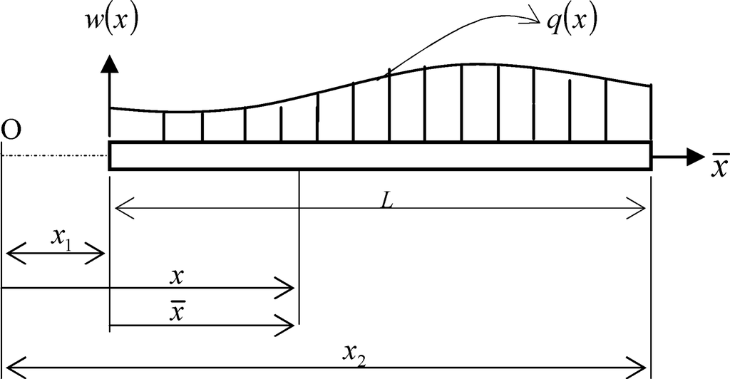

# Viga con flexión asimétrica

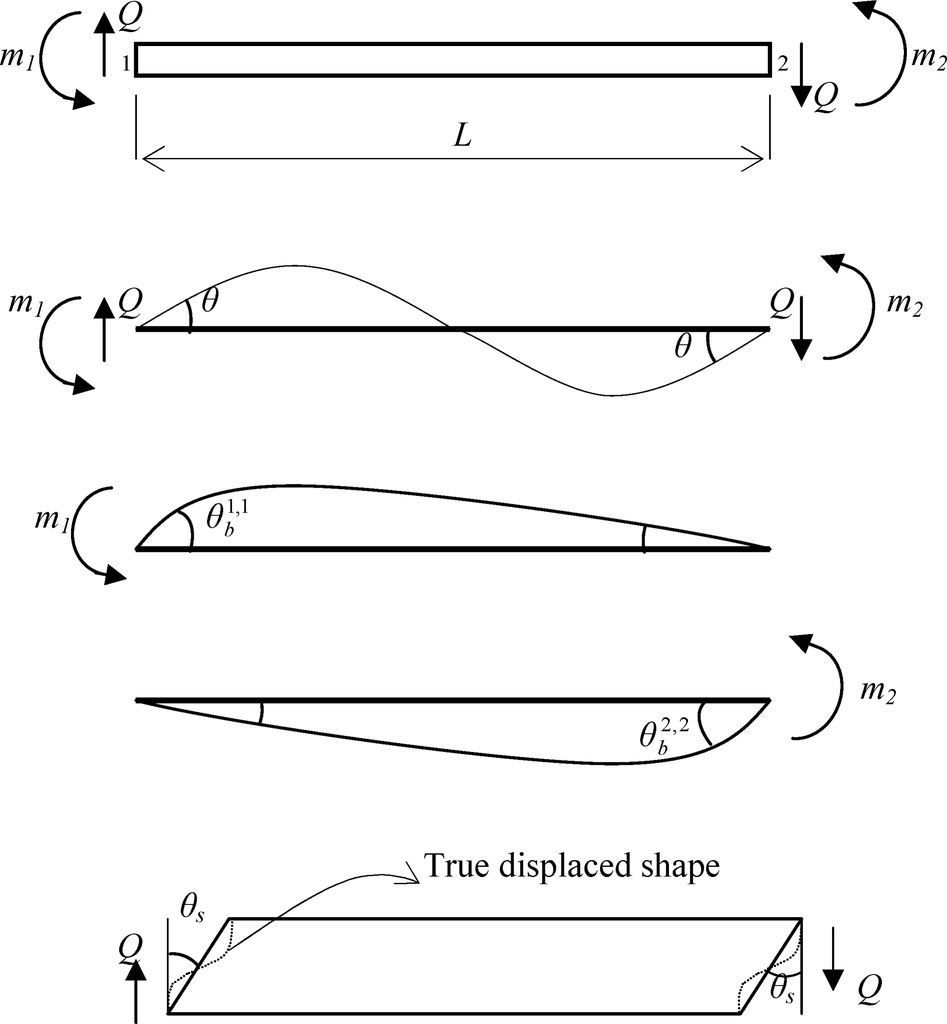

Vamos a obtener el ángulo de giro debido a la flexión para la viga anterior con Euler-Bernoulli.

```python
from sympy import *
from sympy.physics.continuum_mechanics.beam import Beam
from sympy.abc import x

# %%
m, Q = symbols('m Q')
E, I, L = symbols('E I L', positive=True)
# %%
viga = Beam(L, E, I)
# %% Apoyos
viga.apply_support(0, 'roller')
viga.apply_support(L, 'roller')
# %% Momentos y Cargas
viga.apply_load(-m, 0, -2)
viga.apply_load(-m, L, -2)
viga.apply_load( Q, 0, -1)
viga.apply_load(-Q, L, -1)
# %% Reacciones
R_0, R_L = symbols('R_0 R_L')
viga.apply_load(R_0, 0, -1)
viga.apply_load(R_L, L, -1)
viga.solve_for_reaction_loads(R_0, R_L)
# %%
# viga.slope().subs(x, L)
print('θ(x)  = \n'); viga.slope()
theta__1_b = viga.slope().subs(x,0)
print('θ_b¹(x)  = \n'); theta__1_b # Ángulo de giro debido a ambos momentos en el nodo 1.
```

```
θ(x)  =
```

$\displaystyle \frac{\frac{L m}{6} + \frac{Q {\left\langle x \right\rangle}^{2}}{2} - \frac{Q {\left\langle - L + x \right\rangle}^{2}}{2} - m {\left\langle x \right\rangle}^{1} - m {\left\langle - L + x \right\rangle}^{1} + 3 \left(- \frac{Q}{6} + \frac{m}{3 L}\right) {\left\langle x \right\rangle}^{2} + 3 \left(\frac{Q}{6} - \frac{m}{3 L}\right) {\left\langle - L + x \right\rangle}^{2}}{E I}$

```
θ_b¹(x)  =
```

$\displaystyle \frac{L m}{6 E I}$

Sabemos que para la viga de Timoshenko se cumple que $Q(x)= G(x) \bar{A} (x) \theta_s (x)$ y, por lo tanto, $\theta_s(x) = \frac{Q(x)}{G \bar{A}}$ (eso es $V(x)= G(x) A^*(x) \varphi(x)$ y $\varphi(x)= \frac{V(x)}{G A^*}$ en la notación del *main* de Sólidos).

```python
# %% Definición de variables
from sympy.abc import G
Abar = symbols('Abar')
m_1, m_2 = symbols('m_1 m_2')

theta_s = Q /(G*Abar)
sympify('Eq(theta_s, Q /(G*Abar))', evaluate=False)

theta__11_s, theta__12_s = symbols('theta__11_s theta__12_s')

Q1 = m_1/L; sympify('Eq(Q, m_1/L)', evaluate=False)
theta__11_s = Q1/(G*Abar)
print('θₛ¹\'¹ = \n'); theta__11_s

Q2 = m_2/L; sympify('Eq(Q, m_2/L)', evaluate=False)
theta__12_s = Q2/(G*Abar)
print('θₛ¹\'² = \n'); theta__12_s
```

$\displaystyle \theta_{s} = \frac{Q}{\bar{A} G}$

$\displaystyle Q = \frac{m_{1}}{L}$

```
θₛ¹'¹ =
```

$\displaystyle \frac{m_{1}}{\bar{A} G L}$

$\displaystyle Q = \frac{m_{2}}{L}$

```
θₛ¹'² =
```

$\displaystyle \frac{m_{2}}{\bar{A} G L}$

```python
theta__1_s  = theta__11_s + theta__12_s
print('θₛ¹ = \n'); theta__1_s

# Resulta
theta__1_s = (2*m)/(Abar*G*L)
# Pero
Eq(m_1, m_2)
# Entonces
sympify('Eq(theta__1_s, (2*m)/(Abar*G*L))', evaluate=False)
```

```
θₛ¹ =
```

$\displaystyle \frac{m_{1}}{\bar{A} G L} + \frac{m_{2}}{\bar{A} G L}$

$\displaystyle m_{1} = m_{2}$

$\displaystyle \theta^{1}_{s} = \frac{2 m}{\bar{A} G L}$

# Analytical Bending and Shear Rotation Interdependent Shape Function

Por otro lado, tenemos que

```python
phi_b = theta__1_b/(theta__1_b + theta__1_s)
sympify('Eq(varphi_b, theta__1_b/(theta__1_b + theta__1_s))', evaluate=False)

sympify('varphi_b'); print('= \n')
sp.simplify(phi_b)
```

$\displaystyle \varphi_{b} = \frac{\theta^{1}_{b}}{\theta^{1}_{b} + \theta^{1}_{s}}$

$\displaystyle \varphi_{b}$

$\displaystyle \frac{\bar{A} G L^{2}}{\bar{A} G L^{2} + 12 E I}$

```python
Omega = (12*E*I)/(L**2 * G * Abar)
print('Ω = \n'); Omega

sympify('Eq(varphi_b, 1/(1+Omega))', evaluate=False)

simplify(1/(1+Omega)) - simplify(phi_b) == 0 # ¿Son iguales?
```

```
Ω =
```

$\displaystyle \frac{12 E I}{\bar{A} G L^{2}}$

$\displaystyle \varphi_{b} = \frac{1}{\Omega + 1}$

```
True
```

```python
phi_s = theta__1_s/(theta__1_b + theta__1_s)
sympify('varphi_b'); print('= \n'); sp.simplify(phi_s)

sympify('Eq(varphi_s, Omega/(1+Omega))', evaluate=False)

simplify(Omega/(1+Omega)) - simplify(phi_s) == 0 # ¿Son iguales?
```

$\displaystyle \varphi_{b}$

$\displaystyle \frac{12 E I}{\bar{A} G L^{2} + 12 E I}$

$\displaystyle \varphi_{s} = \frac{\Omega}{\Omega + 1}$

```
True
```

$\theta (x) = \theta_b (x) \cdot \varphi_b + \theta_s (x) \cdot \varphi_s$

Aquí, $\theta$ representa la rotación total de la sección transversal; $\theta_b$ es la rotación por flexión y $\theta_s$ la rotación promedio por cortante.

Además, se debe cumplir con la condición $\varphi_b + \varphi_s = 1$ (condición de rotación rígida).

Se propone lo siguiente $\theta(x)=\frac{d w (x)}{d x} \cdot \varphi_{b}+\theta_{s}(x) \cdot \varphi_{s}$

# Moment-Curvature Equation

```python
from sympy.abc import theta, x, E, I

M = sp.Function('M')(x)
w = sp.Function('w')(x)

theta = sp.Function('theta')(x)

Eq(diff(theta, x), M/(E*I))
theta = diff(w, x) * phi_b + theta_s * phi_s
theta
```

$\displaystyle \frac{d}{d x} \theta{\left(x \right)} = \frac{M{\left(x \right)}}{E I}$

$\displaystyle \frac{L m \frac{d}{d x} w{\left(x \right)}}{6 E I \left(\frac{L m}{6 E I} + \frac{2 m}{\bar{A} G L}\right)} + \frac{2 Q m}{\bar{A}^{2} G^{2} L \left(\frac{L m}{6 E I} + \frac{2 m}{\bar{A} G L}\right)}$

$\frac{d}{d x}\left(\frac{d w(x)}{d x} \cdot \varphi_{b}+\theta_{s}(x) \cdot \varphi_{s}\right)=\frac{M(x)}{E I}$

$M(x)= \underbrace{E I_1 \frac{\mathrm{d} ^2 w(x)}{\mathrm{d} x ^2} \varphi_b}_{M_1 (x)} + \underbrace{E I_2 \frac{\mathrm{d} \theta_s (x)}{\mathrm{d} x} \varphi_s}_{M_2 (x)}$

$b_1 = b \varphi_b$

$b_2 = b \varphi_s$

$\kappa_b = \frac{\mathrm{d} ^2 w(x)}{\mathrm{d} x ^2} $

$\kappa_s = \frac{\mathrm{d} \theta_s (x)}{\mathrm{d} x}$

# Principio de la energía potencial mínima

$\Pi=\left(\kappa_{b}(w), \kappa_{s}\left(\theta_{s}\right)\right)=\Pi(w, \theta) \frac{1}{2} \int_{0}^{L}\left[E I_{1} \kappa_{b}^{2}\right] d x +\frac{1}{2} \int_{0}^{L}\left[E I_{2} \kappa_{s}^{2}\right] d x-\int_{0}^{L} q(x) w d x$

Se deriva el funcional

$d \Pi(w, \theta) [\delta w, \delta \theta_s] = \frac{1}{2} \int_{0}^{L}\left[\delta \kappa_b E I_{1} \kappa_b \right] d x +\frac{1}{2} \int_{0}^{L} \left[\delta \kappa_s E I_{2} \kappa_s \right] d x-\int_{0}^{L} q(x) \delta w d x = 0$

$\delta \kappa_b = \left [ \delta \left ( \frac{d^2 w}{d x^2} \right ) \right ]$

$\delta \kappa_s = \left [ \delta \left ( \frac{d \theta_s}{d x} \right ) \right ]$

De allí se concluye que $w$ requiere continuidad $C_1$ y $\theta_s$ requiere $C_0$, lo cual implica que $w$ se debe interpolar con polinomios de Hermite, mientras que $\theta_s$ se interpola con polinomios de Lagrange.

# Funciones de interpolación de Hermite para w(x)

Polinomio de grado $2n-1=2 \cdot 2 -1 =3$.

```
N₁(ξ)  =
```

$\displaystyle 2 \xi^{3} - 3 \xi^{2} + 1$

```
Nb₁(ξ) =
```

$\displaystyle \xi^{3} - 2 \xi^{2} + \xi$

```
N₂(ξ)  =
```

$\displaystyle - 2 \xi^{3} + 3 \xi^{2}$

```
Nb₂(ξ) =
```

$\displaystyle \xi^{3} - \xi^{2}$

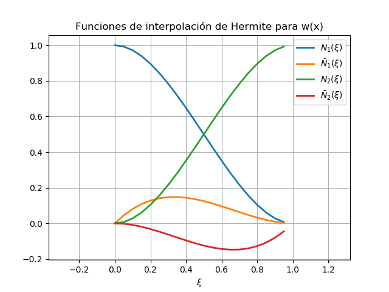

$\displaystyle \left( -0.04750000000000001, \ 0.9975, \ -0.20526875000000003, \ 1.05739375\right)$

```python
import numpy as np
import matplotlib.pyplot as plt

# %%Definición de variables

xi, u1, u2, u1p, u2p = sp.symbols('xi u1 u2 u1p u2p')
x1 =  0
x2 =  1

# Jacobiano
xbar, x1_, x_ = sp.symbols('xbar x1_ x_')
xbar = x_ - x1_
xi_ = xbar/L
dxi_dx = sp.diff(xi_, x_)

# NOTA: el siguiente comando solo se puede realizar si x(xi) es una función
# continua e inyectiva. Este es nuestro caso:
# https://en.wikipedia.org/wiki/Inverse_functions_and_differentiation
dx_dxi = 1/dxi_dx

# %%Funciones de forma lagrangianas

L1 = sp.interpolate([(0, 1), (1, 0)], xi)
L2 = sp.interpolate([(0, 0), (1, 1)], xi)

# %%Se calculan los polinomios Pi y

P1 = (1 - 2*(sp.diff(L1, xi)).subs(xi, x1)*(xi-x1))*L1**2
P2 = (1 - 2*(sp.diff(L2, xi)).subs(xi, x2)*(xi-x2))*L2**2
Q1 = (xi-x1)*L1**2
Q2 = (xi-x2)*L2**2

# %%Se calcula el polinomio interpolador

u = sp.simplify(P1*u1 + P2*u2 + Q1*u1p + Q2*u2p)

# %%Se calculan las funciones de forma
N1  = sp.expand(u.subs([(u1, 1), (u1p, 0), (u2, 0), (u2p, 0)]))
N1b = sp.expand(u.subs([(u1, 0), (u1p, 1), (u2, 0), (u2p, 0)]))
N2  = sp.expand(u.subs([(u1, 0), (u1p, 0), (u2, 1), (u2p, 0)]))
N2b = sp.expand(u.subs([(u1, 0), (u1p, 0), (u2, 0), (u2p, 1)]))

# %%Se muestran los resultados

print(f'N₁(ξ)  = \n'); N1
print(f'Nb₁(ξ) = \n'); N1b
print(f'N₂(ξ)  = \n'); N2
print(f'Nb₂(ξ) = \n'); N2b

# %%Se dibujan las funciones de forma Hermitianas

N1p  = sp.lambdify([xi], N1)
N1bp = sp.lambdify([xi], N1b)
N2p  = sp.lambdify([xi], N2)
N2bp = sp.lambdify([xi], N2b)
xical = np.arange(0, 1, 0.05)  # Puntos de evaluación de las funciones.

N__w = sp.Matrix([N1, N1b, N2, N2b]).T
B__w = sp.diff(N__w, xi, 2)*(dxi_dx)**2

fig, ax = plt.subplots()
ax.plot(xical, N1p(xical), linewidth=2, label=r'$N_1(\xi)$')
ax.plot(xical, N1bp(xical), linewidth=2, label=r'$\bar{N}_1(\xi)$')
ax.plot(xical, N2p(xical), linewidth=2, label=r'$N_2(\xi)$')
ax.plot(xical, N2bp(xical), linewidth=2, label=r'$\bar{N}_2(\xi)$')

ax.axis('equal')
ax.set_title('Funciones de interpolación de Hermite para w(x)')
ax.set_xlabel(r'$\xi$')
ax.legend()
ax.grid()
plt.show()
```

# Interpolación lineal de Lagrange para θs (x)

```
N(ξ)  =
```

$\displaystyle \left[\begin{matrix}1 - \xi & \xi\end{matrix}\right]$

```
B(ξ)  =
```

$\displaystyle \left[\begin{matrix}- \frac{1}{L} & \frac{1}{L}\end{matrix}\right]$

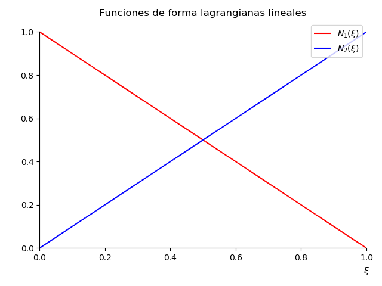

```python
xi, x, x1, x2= sp.symbols('xi x x1 x2')

# %% Defino las posiciones de los nodos
x2 = x1 + L  # Todos están igualmente espaciados

N__theta_1 = sp.factor(sp.nsimplify(sp.interpolate([(0,1), (1,0)], xi)))
N__theta_2 = sp.factor(sp.nsimplify(sp.interpolate([(0,0), (1,1)], xi)))

# %% Definición de la matriz de forma N y matriz de deformación del elemento B
N__theta = sp.Matrix([[N__theta_1, N__theta_2]])
print(f'N(ξ)  = \n'); N__theta
B__theta = sp.simplify(sp.diff(N__theta, xi))*dxi_dx
print(f'B(ξ)  = \n'); B__theta

# Grafico las funciones de forma
p = sp.plot((N__theta_1, (xi, 0, 1)),
            (N__theta_2, (xi, 0, 1)), show=False)
p[0].line_color = 'red'
p[0].label = r'$N_1(\xi)$'

p[1].line_color = 'blue'
p[1].label = r'$N_2(\xi)$'

p.xlabel = r'$\xi$'
p.ylabel = ' '
p.title  = 'Funciones de forma lagrangianas lineales'
p.legend = True
p.show()
```

$\mathbf{\bar{w}} = \left [ \bar{w_1} \: \bar{\theta_1} \: \bar{w_2} \: \bar{\theta_2} \right ]^T$

$\mathbf{\bar{\theta_s}} = \left [ \bar{\theta_1} \: \bar{\theta_2} \right ]^T$

$w(x) = \mathbf{N^w \bar{w}}$

$\theta_s(x) = \mathbf{N^{\theta_s} \bar{\theta_s}}$

$\delta \kappa_{b}=\left[\delta\left(\frac{d^{2} w}{d x^{2}}\right)\right], \quad \delta \kappa_{s}=\left[\delta\left(\frac{d \theta_{s}}{d x}\right)\right]$

$\delta w =\delta \mathbf{N}^w \delta \mathbf{\bar{w}} \qquad \delta \theta_s =\delta \mathbf{N}^{\theta_s} \delta \mathbf{\bar{\theta_s}}$

$\delta \kappa_b =\delta \mathbf{B}^w \delta \mathbf{\bar{w}} \qquad \delta \kappa_s =\delta \mathbf{B}^{\theta_s} \delta \mathbf{\bar{\theta_s}}$

$\kappa_b = (\mathbf{N}^w)'' \mathbf{\bar{w}} = \mathbf{B}^w \mathbf{\bar{w}}$

$\kappa_s = (\mathbf{N}^\theta)' \mathbf{\bar{\theta_s}} = \mathbf{B}^{\theta_s} \mathbf{\bar{\theta_s}}$

$\mathbf{B^w} = \left [ (N_1^w )'' \: (N_2^w )'' \: (N_3^w )'' \: (N_4^w )'' \right ]$

$\mathbf{B^\theta_s} = \left [ (N_1^{\theta_s} )' \: (N_2^{\theta_s} )' \right ]$

$\int_{0}^1 \left [ (\mathbf{B^w}^T \delta \mathbf{\bar{w}}) E I_1 \mathbf{B^w} \mathbf{\bar{w}} \right ] L d \xi + \int_{0}^1 \left [ (\mathbf{B^{\theta_s}}^T \delta \mathbf{\bar{\theta_s}}) E I_2 \mathbf{B^{\theta_s}} \mathbf{\bar{\theta_s}} \right ] L d \xi - \int_{0}^1 q(x)(\mathbf{N^w})^T \delta \mathbf{\bar{w}} L d \xi = 0$

$(\delta \mathbf{\bar{w}})^T \int_{0}^1 \left [ (\mathbf{B^w}^T \delta \mathbf{\bar{w}}) E I_1 \mathbf{B^w} \mathbf{\bar{w}} \right ] L d \xi + (\delta \mathbf{\bar{\theta_s}})^T \int_{0}^1 \left [ (\mathbf{B^{\theta_s}}^T \delta \mathbf{\bar{\theta_s}}) E I_2 \mathbf{B^{\theta_s}} \mathbf{\bar{\theta_s}} \right ] L d \xi - (\delta \mathbf{\bar{w}})^T \int_{0}^1 q(x)(\mathbf{N^w})^T \delta \mathbf{\bar{w}} L d \xi = 0$

$\begin{bmatrix} \delta \bar{w}^T\\ \delta \bar{\theta_s}^T \end{bmatrix} \cdot \begin{bmatrix} \int_{0}^1 \left [ (\mathbf{B^w}^T \delta \mathbf{\bar{w}}) E I_1 \mathbf{B^w} \mathbf{\bar{w}} \right ] L d \xi - \int_{0}^1 q(x)(\mathbf{N^w})^T \delta \mathbf{\bar{w}} L d \xi\\ \int_{0}^1 \left [ (\mathbf{B^{\theta_s}}^T \delta \mathbf{\bar{\theta_s}}) E I_2 \mathbf{B^{\theta_s}} \mathbf{\bar{\theta_s}} \right ] L d \xi \end{bmatrix}= \begin{bmatrix} 0\\ 0 \end{bmatrix}$

$(\delta \mathbf{\bar{w}})^T \int_{0}^1 \left [ (\mathbf{B^w}^T \delta \mathbf{\bar{w}}) E I_1 \mathbf{B^w} \mathbf{\bar{w}} \right ] L d \xi - (\delta \mathbf{\bar{w}})^T \int_{0}^1 q(x)(\mathbf{N^w})^T \delta \mathbf{\bar{w}} L d \xi = 0$

$(\delta \mathbf{\bar{\theta_s}})^T \int_{0}^1 \left [ (\mathbf{B^{\theta_s}}^T \delta \mathbf{\bar{\theta_s}}) E I_2 \mathbf{B^{\theta_s}} \mathbf{\bar{\theta_s}} \right ] L d \xi = 0$

$\int_{0}^1 \left [ (\mathbf{B^w}^T \mathbf{\bar{w}}) E I_1 \mathbf{B^w} \mathbf{\bar{w}} \right ] L d \xi - \int_{0}^1 q(x)(\mathbf{N^w})^T \mathbf{\bar{w}} L d \xi = 0$

$\int_{0}^1 \left [ (\mathbf{B^{\theta_s}}^T \mathbf{\bar{\theta_s}}) E I_2 \mathbf{B^{\theta_s}} \mathbf{\bar{\theta_s}} \right ] L d \xi = 0$

$K^e_{\kappa_b} = \int_{0}^1 \left [ (\mathbf{B^w}^T \mathbf{\bar{w}}) E I_1 \mathbf{B^w} \mathbf{\bar{w}} \right ] L d \xi$

$K^e_{\kappa_s} = \int_{0}^1 \left [ (\mathbf{B^{\theta_s}}^T \mathbf{\bar{\theta_s}}) E I_2 \mathbf{B^{\theta_s}} \mathbf{\bar{\theta_s}} \right ] L d \xi$

$f^e= \int_{0}^1 q(x)(\mathbf{N^w})^T \mathbf{\bar{w}} L d \xi$

$K^e = K^e_{\kappa_b} + K^e_{\kappa_s}$

$K^e \bar{d^e}- f^e = 0$

$\bar{d^e} = \left [ \bar{w_1} \: \bar{\theta_1} \: \bar{w_2} \: \bar{\theta_2} \right ]^T$

```python
phi_b, phi_s = sp.symbols('varphi_b varphi_s')
from sympy.abc import q

I_b = I*phi_b # Inercias complementarias
I_s = I*phi_s

Kb =   integrate(B__w.T    *E*I_b*B__w    *dx_dxi, (xi, 0, 1))
Ks =   integrate(B__theta.T*E*I_s*B__theta*dx_dxi, (xi, 0, 1))
f  = q*integrate(                   N__w.T*dx_dxi, (xi, 0, 1)) # Carga constante

print(f'Kb  = \n'); Kb

print(f'Ks  = \n'); Ks

print(f'f   = \n'); f
```

```
Kb  =
```

$\displaystyle \left[\begin{matrix}\frac{12 E I \varphi_{b}}{L^{3}} & \frac{6 E I \varphi_{b}}{L^{3}} & - \frac{12 E I \varphi_{b}}{L^{3}} & \frac{6 E I \varphi_{b}}{L^{3}}\\\frac{6 E I \varphi_{b}}{L^{3}} & \frac{4 E I \varphi_{b}}{L^{3}} & - \frac{6 E I \varphi_{b}}{L^{3}} & \frac{2 E I \varphi_{b}}{L^{3}}\\- \frac{12 E I \varphi_{b}}{L^{3}} & - \frac{6 E I \varphi_{b}}{L^{3}} & \frac{12 E I \varphi_{b}}{L^{3}} & - \frac{6 E I \varphi_{b}}{L^{3}}\\\frac{6 E I \varphi_{b}}{L^{3}} & \frac{2 E I \varphi_{b}}{L^{3}} & - \frac{6 E I \varphi_{b}}{L^{3}} & \frac{4 E I \varphi_{b}}{L^{3}}\end{matrix}\right]$

```
Ks  =
```

$\displaystyle \left[\begin{matrix}\frac{E I \varphi_{s}}{L} & - \frac{E I \varphi_{s}}{L}\\- \frac{E I \varphi_{s}}{L} & \frac{E I \varphi_{s}}{L}\end{matrix}\right]$

```
f   =
```

$\displaystyle \left[\begin{matrix}\frac{L q}{2}\\\frac{L q}{12}\\\frac{L q}{2}\\- \frac{L q}{12}\end{matrix}\right]$

```python
Ks = zeros(4)

Ks[1,1] =  1; Ks[3,3] =  1 # La matriz era de 2x2, se expande a 4x4
Ks[1,3] = -1; Ks[3,1] = -1
Ks *= (E*I*phi_s/L)

print(f'Ks  = \n'); Ks

K = Kb + Ks
print(f'K   = \n'); K
```

```
Ks  =
```

$\displaystyle \left[\begin{matrix}0 & 0 & 0 & 0\\0 & \frac{E I \varphi_{s}}{L} & 0 & - \frac{E I \varphi_{s}}{L}\\0 & 0 & 0 & 0\\0 & - \frac{E I \varphi_{s}}{L} & 0 & \frac{E I \varphi_{s}}{L}\end{matrix}\right]$

```
K   =
```

$\displaystyle \left[\begin{matrix}\frac{12 E I \varphi_{b}}{L^{3}} & \frac{6 E I \varphi_{b}}{L^{3}} & - \frac{12 E I \varphi_{b}}{L^{3}} & \frac{6 E I \varphi_{b}}{L^{3}}\\\frac{6 E I \varphi_{b}}{L^{3}} & \frac{E I \varphi_{s}}{L} + \frac{4 E I \varphi_{b}}{L^{3}} & - \frac{6 E I \varphi_{b}}{L^{3}} & - \frac{E I \varphi_{s}}{L} + \frac{2 E I \varphi_{b}}{L^{3}}\\- \frac{12 E I \varphi_{b}}{L^{3}} & - \frac{6 E I \varphi_{b}}{L^{3}} & \frac{12 E I \varphi_{b}}{L^{3}} & - \frac{6 E I \varphi_{b}}{L^{3}}\\\frac{6 E I \varphi_{b}}{L^{3}} & - \frac{E I \varphi_{s}}{L} + \frac{2 E I \varphi_{b}}{L^{3}} & - \frac{6 E I \varphi_{b}}{L^{3}} & \frac{E I \varphi_{s}}{L} + \frac{4 E I \varphi_{b}}{L^{3}}\end{matrix}\right]$

# Cálculo exacto

Se calcula la matriz de rigidez exacta y el vector de fuerzas nodales equivalentes de Timoshenko.

```python
# -*- coding: utf-8 -*-
# Programa para deducir la matriz de rigidez de un elemento de viga de
# Timoshenko a partir de la solucion de la ecuacion diferencial

# %%Importación de librerías
from sympy import symbols, integrate, pretty, simplify, zeros, solve, limit
from sympy import Matrix

# %%Definción de variables
x, L, V, M, t, w, EI, GAast = symbols('x L  V M t w EI GAast')
C1, C2, C3, C4 = symbols('C1, C2, C3, C4')  # Constantes de integración

q = 0

# %%Se calcula la matriz de rigidez
K_T = zeros(4)

V = integrate(q, x) + C1  # Ecuaciónes calculadas con constantes.
M = integrate(V, x) + C2
t = (integrate(M, x) + C3)/EI
w = integrate(t - V/GAast, x) + C4

for i in range(4):

    sol = solve([w.subs(x, 0) - int((i == 0)),  # Condiciones de frontera
                 t.subs(x, 0) - int((i == 1)),
                 w.subs(x, L) - int((i == 2)),
                 t.subs(x, L) - int((i == 3))],
                [C1, C2, C3, C4])

    constantes = [(C1, sol[C1]), (C2, sol[C2]), (C3, sol[C3]), (C4, sol[C4])]

    K_T[:, i] = [+ (V.subs(constantes)).subs(x, 0),   # Y1  se evaluan las
                 - (M.subs(constantes)).subs(x, 0),   # M1  reacciones verticales
                 - (V.subs(constantes)).subs(x, L),   # Y2  y los momentos en los
                 + (M.subs(constantes)).subs(x, L)]   # M2  apoyos

# %%Se imprime la solución
beta = (12 * EI)/(L**2 * GAast)
tmp = EI/((1 + beta)*L**3)
print(f'K_EB = EI/((1 + beta)*L**3)) * \n')
simplify(K_T/tmp)
# Nota: se puede demostrar que:
# K22 = K44 = simplify((4+beta)*L**2)
# K24 = K42 = simplify((2-beta)*L**2)

# Se calcula la matriz de rigidez de Euler-Bernoulli
# Observe que cuando GAast -> Inf, la matriz de rigidez K se vuelve la
# misma matriz de rigidez K de la teoria de Euler-Bernoulli:
#K_EB = limit(K_T, GAast, float('Inf'))
#print('K_EB = (EI/L^3) * \n{pretty(simplify(K_EB/(EI/L**3)))}')

# %%
#Se calculan las fuerzas nodales equivalentes:
w = symbols('w')
# q = w
q = -w

V = integrate(q, x) + C1  # Ecuaciónes calculadas.
M = integrate(V, x) + C2
t = (integrate(M, x) + C3)/EI
w = integrate(t - V/GAast, x) + C4

sol = solve([w.subs(x, 0),  # Condiciones de frontera.
             w.subs(x, L),
             t.subs(x, 0),
             t.subs(x, L)],
            [C1, C2, C3, C4])

constantes = [(C1, sol[C1]), (C2, sol[C2]), (C3, sol[C3]), (C4, sol[C4])]

f = Matrix([-(V.subs(constantes)).subs(x, 0),   # Yi  se evaluan las reacciones verticales y los
            +(M.subs(constantes)).subs(x, 0),   # Mi  momentos en los apoyos y se les multiplica
            +(V.subs(constantes)).subs(x, L),   # Yj  por -1 para estimar la fuerza nodal
            -(M.subs(constantes)).subs(x, L)])  # Mj  equivalente


beta = symbols('beta')
w = symbols('w')
f = simplify(f.subs(GAast, (12 * EI)/(L**2 * beta)))
fc=(-w*L/12)

print(f'\nf = \n(-w*L/12)*\n')
simplify(f/fc)
```

```
K_EB = EI/((1 + beta)*L**3)) *
```

$\displaystyle \left[\begin{matrix}12 & 6 L & -12 & 6 L\\6 L & \frac{12 EI}{GAast} + 4 L^{2} & - 6 L & - \frac{12 EI}{GAast} + 2 L^{2}\\-12 & - 6 L & 12 & - 6 L\\6 L & - \frac{12 EI}{GAast} + 2 L^{2} & - 6 L & \frac{12 EI}{GAast} + 4 L^{2}\end{matrix}\right]$

```
f =
(-w*L/12)*
```

$\displaystyle \left[\begin{matrix}6\\L\\6\\- L\end{matrix}\right]$